# Proyecto 1 Mineria de Datos

Grupo 6

3/25/2022

### Importación de paquetes/librerías

#### Se importan las librerías y paquetes necesarios para procesar, graficar y ordenar los datos de las bases de datos

```r
#install.packages('haven')
library(haven)
library(dplyr)
library(tidyverse)
library(cluster) #Para calcular la silueta
library(e1071)#para cmeans
library(mclust) #mixtures of gaussians
library(fpc) #para hacer el plotcluster
library(NbClust) #Para determinar el número de clusters óptimo
library(factoextra) #Para hacer gráficos bonitos de clustering
library(hopkins) #Para revisar si vale la pena hacer agrupamiento
library(GGally) #Para hacer el conjunto de graficos
library(FeatureImpCluster) #Para revisar la importancia de las variables en los grupos.
library(pheatmap) #Para hacer mapa de calor
```

### Unificación de la base de datos

## PUEDE SALTARSE A IMPORTACION DE BASE DE DATOS UNIFICADA

```r
data2009 <- read_sav('./db/2009.sav')
names(data2009)<-toupper(names(data2009))
data2009 <- data.frame(append(data2009, c(VIAPAR=1), after=13))
data2009 <- data.frame(append(data2009, c(PASIREM=9999), after=16))
data2009 <- data.frame(append(data2009, c(PUEBLOPM=9), after=19))
data2009 <- data.frame(append(data2009, c(ESCOLAM=9), after=23))
data2009 <- data.frame(append(data2009, c(CIUOMAD='IGNORADO'), after=24))
data2009 <- select(data2009, -AÑOREG)
data2009 <- data.frame(append(data2009, c(AÑOREG=2009), after=3))
data2009 <- select(data2009, -AÑOOCU)
data2009 <- data.frame(append(data2009, c(AÑOOCU=2009), after=10))
data2009$EDADM[data2009$EDADM == 999] <- 99
data2010 <- read_sav('./db/2010.sav')
names(data2010)<-toupper(names(data2010))
data2010 <- data.frame(append(data2010, c(PAISREM=9999), after=16))
data2010 <- data.frame(append(data2010, c(PUEBLOPM=9), after=19))
data2010 <- data.frame(append(data2010, c(CIUOMAD='IGNORADO'), after=24))
data2010$DEPREM[data2010$DEPREM == 9999] <- 99
data2010$EDADM[data2010$EDADM == 999] <- 99
data2011 <- read_sav('./db/2011.sav')
names(data2011)<-toupper(names(data2011))
data2011 <- data.frame(append(data2011, c(PAISREM=9999), after=16))
data2011 <- data.frame(append(data2011, c(PUEBLOPM=9), after=19))
data2011 <- data.frame(append(data2011, c(CIUOMAD='IGNORADO'), after=24))
data2011$DEPREM[data2011$DEPREM == 9999] <- 99
data2011$EDADM[data2011$EDADM == 999] <- 99
data2012 <- read_sav('./db/2012.sav')
names(data2012)<-toupper(names(data2012))
data2012 <- data.frame(append(data2012, c(AÑOOCU=2012), after=10))
data2012 <- data.frame(append(data2012, c(PUEBLOPM=9), after=19))
data2012 <- data.frame(append(data2012, c(CIUOMAD='IGNORADO'), after=24))
data2012$DEPREM[data2012$DEPREM == 9999] <- 99
data2012$EDADM[data2012$EDADM == 999] <- 99
data2013 <- read_sav('./db/2013.sav')
names(data2013)<-toupper(names(data2013))
data2013$CIUOMAD <- as.character(data2013$CIUOMAD)
data2013 <- data.frame(append(data2013, c(AÑOOCU=2013), after=10))
data2013 <- data.frame(append(data2013, c(GRETNM=9), after=20))
data2013 <- data.frame(append(data2013, c(OCUPAM=9999), after=25))
data2013$DEPREM[data2013$DEPREM == 9999] <- 99
data2013$EDADM[data2013$EDADM == 999] <- 99
data2014 <- read_sav('./db/2014.sav')
names(data2014)<-toupper(names(data2014))
data2014 <- data.frame(append(data2014, c(AÑOOCU=2014), after=10))
data2014 <- data.frame(append(data2014, c(GRETNM=9), after=20))
data2014 <- data.frame(append(data2014, c(OCUPAM=9999), after=25))
data2014$DEPREM[data2014$DEPREM == 9999] <- 99
data2014$EDADM[data2014$EDADM == 999] <- 99
data2015 <- read_sav('./db/2015.sav')
names(data2015)<-toupper(names(data2015))
data2015 <- data2015 %>% rename(NACIOM = NACIONM)
data2015$CIUOMAD <- as.character(data2015$CIUOMAD)
data2015 <- data.frame(append(data2015, c(GRETNM=9), after=20))
data2015 <- data.frame(append(data2015, c(OCUPAM=9999), after=25))
data2015$EDADM[data2015$EDADM == 999] <- 99
data2016 <- read_sav('./db/2016.sav')
names(data2016)<-toupper(names(data2016))
data2016 <- data2016 %>% rename(NACIOM = NACIONM)
data2016 <- data.frame(append(data2016, c(GRETNM=9), after=20))
data2016 <- data.frame(append(data2016, c(OCUPAM=9999), after=25))
data2016$EDADM[data2016$EDADM == 999] <- 99
data2017 <- read_sav('./db/2017.sav')
names(data2017)<-toupper(names(data2017))
data2017 <- data2017 %>% rename(NACIOM = NACIONM)
data2017 <- data.frame(append(data2017, c(GRETNM=9), after=20))
data2017 <- data.frame(append(data2017, c(OCUPAM=9999), after=25))
data2017$EDADM[data2017$EDADM == 999] <- 99
data2018 <- read_sav('./db/2018.sav')
names(data2018)<-toupper(names(data2018))
data2018 <- data2018 %>% rename(NACIOM = NACIONM)
data2018 <- data.frame(append(data2018, c(AREAG=9), after=6))
data2018 <- data.frame(append(data2018, c(GRETNM=9), after=20))
data2018 <- data.frame(append(data2018, c(OCUPAM=9999), after=25))
data2018$EDADM[data2018$EDADM == 999] <- 99
data2019 <- read_sav('./db/2019.sav')
names(data2019)<-toupper(names(data2019))
data2019 <- data2019 %>% rename(NACIOM = NACIONM)
data2019 <- data.frame(append(data2019, c(AREAG=9), after=6))
data2019 <- data.frame(append(data2019, c(GRETNM=9), after=20))
data2019 <- data.frame(append(data2019, c(OCUPAM=9999), after=25))
data2019$EDADM[data2019$EDADM == 999] <- 99
data2020 <- read_sav('./db/2020.sav')
names(data2020)<-toupper(names(data2020))
data2020 <- data2020 %>% rename(NACIOM = NACIONM)
data2020 <- data.frame(append(data2020, c(AREAG=9), after=6))
data2020 <- data.frame(append(data2020, c(GRETNM=9), after=20))
data2020 <- data.frame(append(data2020, c(OCUPAM=9999), after=25))
data2020$EDADM[data2020$EDADM == 999] <- 99
```

### Unión de las bases de datos

#### Se realiza la unión de todas las bases de datos en una sola tabla

```r
datatotal <- full_join(data2009, data2010)
datatotal <- full_join(datatotal, data2011)
datatotal <- full_join(datatotal, data2012)
datatotal <- full_join(datatotal, data2013)
datatotal <- full_join(datatotal, data2014)
datatotal <- full_join(datatotal, data2015)
datatotal <- full_join(datatotal, data2016)
datatotal <- full_join(datatotal, data2017)
datatotal <- full_join(datatotal, data2018)
datatotal <- full_join(datatotal, data2019)
datatotal <- full_join(datatotal, data2020)
```

### Exportación del set de datos y un breve resumen gráfico

#### Se realiza un resumen del set de datos y se exporta la base de datos completa a un .CSV para su facil manejo con el resto del equipo

```r
summary (datatotal)
```

```
##      DEPREG          MUPREG              MESREG           AÑOREG
##  Min.   : 1.000   Length:36767       Min.   : 1.000   Min.   :2009
##  1st Qu.: 2.000   Class :character   1st Qu.: 3.000   1st Qu.:2011
##  Median : 9.000   Mode  :character   Median : 7.000   Median :2014
##  Mean   : 8.696                      Mean   : 6.454   Mean   :2014
##  3rd Qu.:14.000                      3rd Qu.: 9.000   3rd Qu.:2017
##  Max.   :22.000                      Max.   :12.000   Max.   :2021
##
##      DEPOCU          MUPOCU              AREAG            SEXO
##  Min.   : 1.000   Length:36767       Min.   :1.000   Min.   :1.000
##  1st Qu.: 2.000   Class :character   1st Qu.:1.000   1st Qu.:1.000
##  Median : 9.000   Mode  :character   Median :1.000   Median :1.000
##  Mean   : 8.695                      Mean   :3.516   Mean   :1.507
##  3rd Qu.:14.000                      3rd Qu.:9.000   3rd Qu.:2.000
##  Max.   :22.000                      Max.   :9.000   Max.   :9.000
##
##      DIAOCU          MESOCU           AÑOOCU         TIPAR
##  Min.   : 1.00   Min.   : 1.000   Min.   :2009   Min.   :1.000
##  1st Qu.: 8.00   1st Qu.: 3.000   1st Qu.:2011   1st Qu.:1.000
##  Median :16.00   Median : 7.000   Median :2014   Median :1.000
##  Mean   :15.65   Mean   : 6.485   Mean   :2014   Mean   :1.502
##  3rd Qu.:23.00   3rd Qu.: 9.000   3rd Qu.:2017   3rd Qu.:1.000
##  Max.   :31.00   Max.   :12.000   Max.   :2020   Max.   :9.000
##
##      CLAPAR          VIAPAR          SEMGES           EDADM
##  Min.   :1.000   Min.   :1.000   Min.   :  1.00   Min.   :10.00
##  1st Qu.:1.000   1st Qu.:1.000   1st Qu.: 32.00   1st Qu.:22.00
##  Median :1.000   Median :1.000   Median : 37.00   Median :28.00
##  Mean   :1.683   Mean   :1.205   Mean   : 75.99   Mean   :34.11
##  3rd Qu.:2.000   3rd Qu.:1.000   3rd Qu.: 40.00   3rd Qu.:36.00
##  Max.   :9.000   Max.   :2.000   Max.   :999.00   Max.   :99.00
##
##     PASIREM          DEPREM         MUPREM             PUEBLOPM
##  Min.   :9999    Min.   : 1.00   Length:36767       Min.   :1.000
##  1st Qu.:9999    1st Qu.: 4.00   Class :character   1st Qu.:1.000
##  Median :9999    Median :11.00   Mode  :character   Median :4.000
##  Mean   :9999    Mean   :18.19                      Mean   :5.117
##  3rd Qu.:9999    3rd Qu.:16.00                      3rd Qu.:9.000
##  Max.   :9999    Max.   :99.00                      Max.   :9.000
##  NA's   :33534
```

[output cut: 17 more lines]

```
##  Min.   :1.000   Min.   :  0.0   Min.   :  0.0   Min.   :  0.00
##  1st Qu.:1.000   1st Qu.:  3.0   1st Qu.:  1.0   1st Qu.:  1.00
##  Median :1.000   Median :  8.0   Median :  1.0   Median :  4.00
##  Mean   :3.326   Mean   :101.2   Mean   :113.8   Mean   : 92.18
##  3rd Qu.:6.000   3rd Qu.: 99.0   3rd Qu.: 99.0   3rd Qu.: 99.00
##  Max.   :9.000   Max.   :999.0   Max.   :999.0   Max.   :999.00
##                  NA's   :351     NA's   :142     NA's   :258
##     PAISREM
##  Min.   :  84
##  1st Qu.: 320
##  Median : 320
##  Mean   :2565
##  3rd Qu.: 320
##  Max.   :9999
##  NA's   :3233
```

```r
write.csv(datatotal, "./db/database.csv", row.names=FALSE)
```

### Nuevo set de datos unificado, escritura en un CSV

#### Se importa una nueva tabla desde el nuevo archivo CSV

```r
database <- read.csv("./db/database.csv", stringsAsFactors = F)
```

## INCIDENCIAS ANUALES

#### Se filtra y crea una variable para analisis de incidencias anuales

```r
byyear <- database %>% group_by(database$AÑOOCU) %>% summarise(freq=n()) %>% ungroup()
arrange(byyear, desc(byyear$freq))
```

```
## # A tibble: 12 x 2
##    `database$AÑOOCU`  freq
##                <int> <int>
##  1              2010  3377
##  2              2013  3344
##  3              2011  3266
##  4              2014  3236
##  5              2009  3233
##  6              2016  3161
##  7              2012  3157
##  8              2015  3121
##  9              2017  3033
## 10              2018  2894
## 11              2019  2639
## 12              2020  2306
```

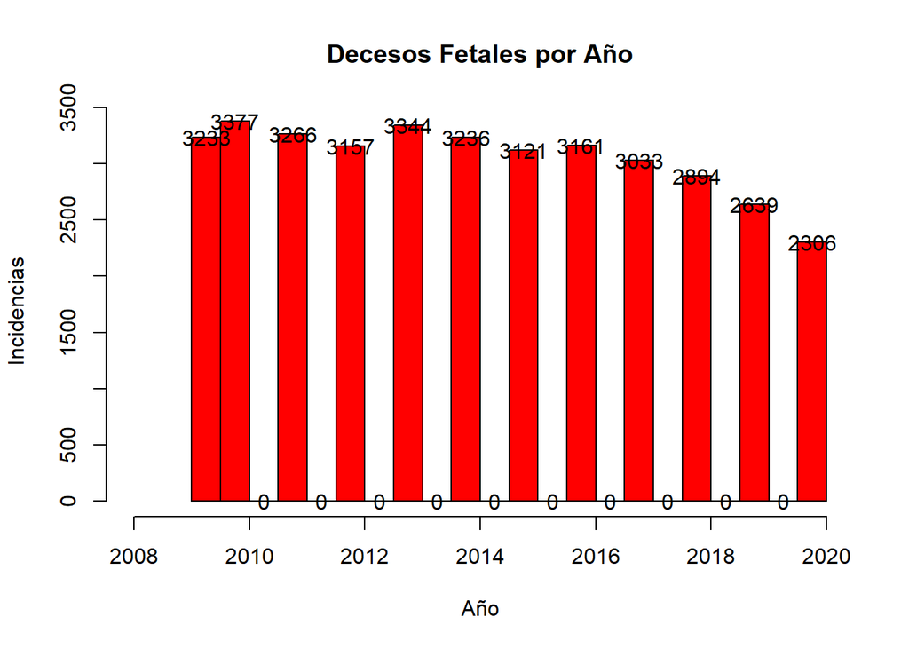

```r
histyearly <-  hist(database$AÑOOCU, main="Decesos Fetales por Año",
xlab="Año", xlim=c(2008,2020), ylab="Incidencias", col="red")
text(histyearly$mids, histyearly$counts, labels=histyearly$counts)
```

#### Analizando las incidencias de decesos fetales por año podemos observar que el año con m ayor número de incidencias es 2010 con 3377 decesos y una tendencia a la baja teniendo una reducción de un 31.71% en 2020.

## INCIDENCIAS POR DEPARTAMENTO DE OCURRENCIA

#### Se filtra y crea una variable para analisis de registros de decesos por depto.

```r
bydept <- database %>% group_by(database$DEPOCU) %>% summarise(freq=n()) %>% ungroup()
bydept$'database$DEPOCU'[bydept$'database$DEPOCU' == 1] <- 'Guatemala'
bydept$'database$DEPOCU'[bydept$'database$DEPOCU' == 2] <- 'El Progreso'
bydept$'database$DEPOCU'[bydept$'database$DEPOCU' == 3] <- 'Sacatepéquez'
bydept$'database$DEPOCU'[bydept$'database$DEPOCU' == 4] <- 'Chimaltenango'
bydept$'database$DEPOCU'[bydept$'database$DEPOCU' == 5] <- 'Escuintla'
bydept$'database$DEPOCU'[bydept$'database$DEPOCU' == 6] <- 'Santa Rosa'
bydept$'database$DEPOCU'[bydept$'database$DEPOCU' == 7] <- 'Sololá'
bydept$'database$DEPOCU'[bydept$'database$DEPOCU' == 8] <- 'Totonicapán'
bydept$'database$DEPOCU'[bydept$'database$DEPOCU' == 9] <- 'Quetzaltenango'
bydept$'database$DEPOCU'[bydept$'database$DEPOCU' == 10] <- 'Suchitepéquez'
bydept$'database$DEPOCU'[bydept$'database$DEPOCU' == 11] <- 'Retalhuleu'
bydept$'database$DEPOCU'[bydept$'database$DEPOCU' == 12] <- 'San Marcos'
bydept$'database$DEPOCU'[bydept$'database$DEPOCU' == 13] <- 'Huehuetenango'
bydept$'database$DEPOCU'[bydept$'database$DEPOCU' == 14] <- 'Quiché'
bydept$'database$DEPOCU'[bydept$'database$DEPOCU' == 15] <- 'Baja Verapaz'
bydept$'database$DEPOCU'[bydept$'database$DEPOCU' == 16] <- 'Alta Verapaz'
bydept$'database$DEPOCU'[bydept$'database$DEPOCU' == 17] <- 'Petén'
bydept$'database$DEPOCU'[bydept$'database$DEPOCU' == 18] <- 'Izabal'
bydept$'database$DEPOCU'[bydept$'database$DEPOCU' == 19] <-  'Zacapa'
bydept$'database$DEPOCU'[bydept$'database$DEPOCU' == 20] <- 'Chiquimula'
bydept$'database$DEPOCU'[bydept$'database$DEPOCU' == 21] <- 'Jalapa'
bydept$'database$DEPOCU'[bydept$'database$DEPOCU' == 22] <- 'Jutiapa'
bydept <- arrange(bydept, desc(bydept$freq))
bydept
```

```
## # A tibble: 22 x 2
##    `database$DEPOCU`  freq
##    <chr>             <int>
##  1 Guatemala          9028
##  2 Alta Verapaz       5085
##  3 Quiché             2740
##  4 Quetzaltenango     2708
##  5 Chimaltenango      2055
##  6 Sololá             2038
##  7 Totonicapán        1852
##  8 Huehuetenango      1625
##  9 Escuintla          1574
## 10 San Marcos         1376
## # ... with 12 more rows
```

## INCIDENCIAS POR LUGAR DE RESIDENCIA DE LA MADRE

#### Ahora se filtra y crea una variable para analisis de registros de decesos en base a lugar de residencia de la madre

```r
bydept2 <- database %>% group_by(database$DEPREM) %>% summarise(freq=n()) %>% ungroup()
bydept2$'database$DEPREM'[bydept2$'database$DEPREM' == 1] <- 'Guatemala'
bydept2$'database$DEPREM'[bydept2$'database$DEPREM' == 2] <- 'El Progreso'
bydept2$'database$DEPREM'[bydept2$'database$DEPREM' == 3] <- 'Sacatepéquez'
bydept2$'database$DEPREM'[bydept2$'database$DEPREM' == 4] <- 'Chimaltenango'
bydept2$'database$DEPREM'[bydept2$'database$DEPREM' == 5] <- 'Escuintla'
bydept2$'database$DEPREM'[bydept2$'database$DEPREM' == 6] <- 'Santa Rosa'
bydept2$'database$DEPREM'[bydept2$'database$DEPREM' == 7] <- 'Sololá'
bydept2$'database$DEPREM'[bydept2$'database$DEPREM' == 8] <- 'Totonicapán'
bydept2$'database$DEPREM'[bydept2$'database$DEPREM' == 9] <- 'Quetzaltenango'
bydept2$'database$DEPREM'[bydept2$'database$DEPREM' == 10] <- 'Suchitepéquez'
bydept2$'database$DEPREM'[bydept2$'database$DEPREM' == 11] <- 'Retalhuleu'
bydept2$'database$DEPREM'[bydept2$'database$DEPREM' == 12] <- 'San Marcos'
bydept2$'database$DEPREM'[bydept2$'database$DEPREM' == 13] <- 'Huehuetenango'
bydept2$'database$DEPREM'[bydept2$'database$DEPREM' == 14] <- 'Quiché'
bydept2$'database$DEPREM'[bydept2$'database$DEPREM' == 15] <- 'Baja Verapaz'
bydept2$'database$DEPREM'[bydept2$'database$DEPREM' == 16] <- 'Alta Verapaz'
bydept2$'database$DEPREM'[bydept2$'database$DEPREM' == 17] <- 'Petén'
bydept2$'database$DEPREM'[bydept2$'database$DEPREM' == 18] <- 'Izabal'
bydept2$'database$DEPREM'[bydept2$'database$DEPREM' == 19] <-  'Zacapa'
bydept2$'database$DEPREM'[bydept2$'database$DEPREM' == 20] <- 'Chiquimula'
bydept2$'database$DEPREM'[bydept2$'database$DEPREM' == 21] <- 'Jalapa'
bydept2$'database$DEPREM'[bydept2$'database$DEPREM' == 22] <- 'Jutiapa'
bydept2$'database$DEPREM'[bydept2$'database$DEPREM' == 23] <- 'Extranjero'
bydept2$'database$DEPREM'[bydept2$'database$DEPREM' == 99] <- 'Ignorado'
bydept2 <- arrange(bydept2, desc(bydept2$freq))
head(bydept2,24)
```

```
## # A tibble: 24 x 2
##    `database$DEPREM`  freq
##    <chr>             <int>
##  1 Guatemala          6345
##  2 Alta Verapaz       4707
##  3 Ignorado           3586
##  4 Quiché             2817
##  5 Quetzaltenango     2186
##  6 Chimaltenango      2108
##  7 Totonicapán        1977
##  8 Sololá             1705
##  9 Huehuetenango      1485
## 10 San Marcos         1439
## # ... with 14 more rows
```

## INCIDENCIAS POR TIPO DE ASISTENCIA RECIBIDA

```r
byassist <- database %>% group_by(database$ASISREC) %>% summarise(freq=n()) %>% ungroup()
byassist$'database$ASISREC'[byassist$'database$ASISREC' == 1] <- 'Médica'
byassist$'database$ASISREC'[byassist$'database$ASISREC' == 2] <- 'Paramédica'
byassist$'database$ASISREC'[byassist$'database$ASISREC' == 3] <- 'Comadrona'
byassist$'database$ASISREC'[byassist$'database$ASISREC' == 4] <- 'Empírica'
byassist$'database$ASISREC'[byassist$'database$ASISREC' == 5] <- 'Ninguna'
byassist$'database$ASISREC'[byassist$'database$ASISREC' == 9] <- 'Ignorado'
byassist <- arrange(byassist, desc(byassist$freq))
byassist
```

```
## # A tibble: 6 x 2
##   `database$ASISREC`  freq
##   <chr>              <int>
## 1 Médica             25304
## 2 Comadrona           5491
## 3 Ninguna             2945
## 4 Ignorado            2167
## 5 Paramédica           601
## 6 Empírica             259
```

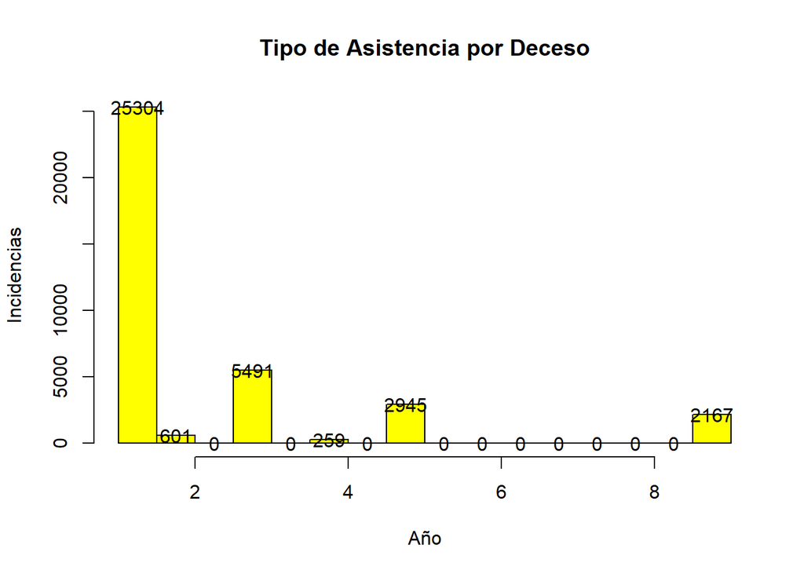

| Código | Asistencia Recibida |
| --- | --- |
| 1 | Médica |
| 2 | Paramédica |
| 3 | Comadrona |
| 4 | Empírica |
| 5 | Ninguna |
| 9 | Ignorado |

```r
histassist <-  hist(database$ASISREC, main="Tipo de Asistencia por Deceso",
xlab="Año", xlim=c(1,9), ylab="Incidencias", col="yellow")
text(histassist$mids, histassist$counts, labels=histassist$counts)
```

#### Se puede observar que existe una mayoría de decesos fetales que son asistidos en centros médicos

## INCIDENCIAS POR NIVEL DE ESCOLARIDAD

#### Se crea un registro personalizado de incidencias por nivel de escolaridad

```r
byeduc <- database %>% group_by(database$ESCOLAM) %>% summarise(freq=n()) %>% ungroup()
byeduc$'database$ESCOLAM'[byeduc$'database$ESCOLAM' == 1] <- 'Primaria'
byeduc$'database$ESCOLAM'[byeduc$'database$ESCOLAM' == 2] <- 'Básica'
byeduc$'database$ESCOLAM'[byeduc$'database$ESCOLAM' == 3] <- 'Diversificado'
byeduc$'database$ESCOLAM'[byeduc$'database$ESCOLAM' == 4] <- 'Universitario'
byeduc$'database$ESCOLAM'[byeduc$'database$ESCOLAM' == 5] <- 'Post Grado'
byeduc$'database$ESCOLAM'[byeduc$'database$ESCOLAM' == 6] <- 'Doctorado'
byeduc$'database$ESCOLAM'[byeduc$'database$ESCOLAM' == 9] <- 'Ignorado'
byeduc$'database$ESCOLAM'[byeduc$'database$ESCOLAM' == 0] <- 'Ninguno'
byeduc <- arrange(byeduc, desc(byeduc$freq))
head(byeduc,8)
```

```
## # A tibble: 7 x 2
##   `database$ESCOLAM`  freq
##   <chr>              <int>
## 1 Primaria           11940
## 2 Básica             10888
## 3 Ignorado            6267
## 4 Universitario       3932
## 5 Diversificado       3267
## 6 Post Grado           470
## 7 Doctorado              3
```

#### Se puede observar que existe una tendencia de embarazos resultantes en perdida entre personas que han unicamente cursado la educación de primaria y básicos. Con un gran numero de ‘ignorados’ que tienen una alta probabilidad de encontrarse en una de estas categorías

## INCIDENCIAS SEGUN LA EDAD DE LA MADRE, EN INTERVALOS

#### Se crea un registro personalizado de incidencias por rangos de edad de la madre

```r
byage <- data.frame(EDADM=c(database$EDADM))
byage$EDADM[byage$EDADM >= 10 & byage$EDADM <=15] <- '10-15 años'
byage$EDADM[byage$EDADM > 15 & byage$EDADM <=20] <- '15-20 años'
byage$EDADM[byage$EDADM > 20 & byage$EDADM <=25] <- '20-25 años'
byage$EDADM[byage$EDADM > 25 & byage$EDADM <=30] <- '25-30 años'
byage$EDADM[byage$EDADM > 30 & byage$EDADM <=35] <- '30-35 años'
byage$EDADM[byage$EDADM > 35 & byage$EDADM <=40] <- '35-40 años'
byage$EDADM[byage$EDADM > 40 & byage$EDADM <=45] <- '40-45 años'
byage$EDADM[byage$EDADM > 45 & byage$EDADM <=50] <- '45-50 años'
byage$EDADM[byage$EDADM > 50 & byage$EDADM <=55] <- '50-55 años'
byage$EDADM[byage$EDADM > 55 & byage$EDADM <=60] <- '55-60 años'
byage$EDADM[byage$EDADM >= 99] <- 'Ignorado'
byage2 <- byage %>% group_by(byage$EDADM) %>% summarise(freq=n()) %>% ungroup()
byage2 <- arrange(byage2, desc(byage2$freq))
byage2
```

```
## # A tibble: 11 x 2
##    `byage$EDADM`  freq
##    <chr>         <int>
##  1 20-25 años     7828
##  2 25-30 años     6886
##  3 15-20 años     6180
##  4 30-35 años     6046
##  5 35-40 años     4244
##  6 Ignorado       3329
##  7 40-45 años     1567
##  8 10-15 años      590
##  9 45-50 años       88
## 10 50-55 años        8
## 11 55-60 años        1
```

#### Se puede observar que existe una alta concentración de decesos durante embarazos en las edades de entre 15 y 40 años, con datos atípicos fuera de este rango. Teniendo un 9% de los datos categorizados como ignorado.

## Regresión Lineal

```r
database4 <- fread("./db/database.csv", select = c("DEPREG","DEPOCU", "AÑOOCU", "EDADM", "ESCOLAM","DEPREM"))
cor(database4)
```

```
##              DEPREG      DEPOCU      AÑOOCU       EDADM    ESCOLAM      DEPREM
## DEPREG   1.00000000  0.99561446  0.03385945 -0.07021079 -0.1197947  0.07615347
## DEPOCU   0.99561446  1.00000000  0.03409430 -0.07010661 -0.1204162  0.07507813
## AÑOOCU   0.03385945  0.03409430  1.00000000 -0.31402269 -0.3459553 -0.25682737
## EDADM   -0.07021079 -0.07010661 -0.31402269  1.00000000  0.4320977  0.70872116
## ESCOLAM -0.11979474 -0.12041617 -0.34595530  0.43209774  1.0000000  0.56133310
## DEPREM   0.07615347  0.07507813 -0.25682737  0.70872116  0.5613331  1.00000000
```

```r
regresion <- lm(DEPOCU ~., data = database4)
summary(regresion)
```

```
##
## Call:
## lm(formula = DEPOCU ~ ., data = database4)
##
## Residuals:
##      Min       1Q   Median       3Q      Max
## -19.9434  -0.0236  -0.0010   0.0241  19.9628
##
## Coefficients:
##               Estimate Std. Error  t value Pr(>|t|)
## (Intercept) -0.2413272  1.9417713   -0.124   0.9011
## DEPREG       0.9957481  0.0005066 1965.615   <2e-16 ***
## AÑOOCU       0.0001394  0.0009629    0.145   0.8849
## EDADM        0.0002066  0.0002015    1.025   0.3054
## ESCOLAM     -0.0023731  0.0013527   -1.754   0.0794 .
## DEPREM      -0.0001409  0.0001749   -0.806   0.4205
## ---
## Signif. codes:  0 '***' 0.001 '**' 0.01 '*' 0.05 '.' 0.1 ' ' 1
##
## Residual standard error: 0.5711 on 36761 degrees of freedom
## Multiple R-squared:  0.9912, Adjusted R-squared:  0.9912
## F-statistic: 8.329e+05 on 5 and 36761 DF,  p-value: < 2.2e-16
```

## INCIDENCIAS POR CAUSA, TOP 10

```r
bycause <- data.frame(Causa=c(database$CAUDEF))
bycause$Causa[bycause$Causa == 'P95X'] <- 'Muerte fetal de causa no especificada'
bycause$Causa[bycause$Causa == 'P209'] <- 'Hipoxia intrauterina, no especificada'
bycause$Causa[bycause$Causa == 'P964'] <- 'Terminación del embarazo, feto y recién nacido'
bycause$Causa[bycause$Causa == 'P073'] <- 'Otros recién nacidos pretérmino'
bycause$Causa[bycause$Causa == 'Q899'] <- 'Malformación congénita, no especificada'
bycause$Causa[bycause$Causa == 'Q897'] <- 'Malformaciones congénitas múltiples, no clasificadas en otra parte'
bycause$Causa[bycause$Causa == 'P025'] <- 'Feto y recién nacido afectados por otra compresión del cordón umbilical'
bycause$Causa[bycause$Causa == 'Q000'] <- 'Anencefalia'
bycause$Causa[bycause$Causa == 'P021'] <- 'Feto y recién nacido afectados por otras formas de desprendimiento y de hemorragia placentarios'
bycause$Causa[bycause$Causa == 'P000'] <- 'Feto y recién nacido afectados por trastornos hipertensivos de la madre'
bycause <- bycause %>% group_by(bycause$Causa) %>% summarise(freq=n()) %>% ungroup()
bycause <- arrange(bycause, desc(bycause$freq))

head(bycause, 10)
```

```
## # A tibble: 10 x 2
##    `bycause$Causa`                                                          freq
##    <chr>                                                                   <int>
##  1 Muerte fetal de causa no especificada                                   16472
##  2 Hipoxia intrauterina, no especificada                                   11813
##  3 Terminación del embarazo, feto y recién nacido                            876
##  4 Otros recién nacidos pretérmino                                           647
##  5 Malformación congénita, no especificada                                   641
##  6 Malformaciones congénitas múltiples, no clasificadas en otra parte        588
##  7 Feto y recién nacido afectados por otra compresión del cordón umbilical   585
##  8 Anencefalia                                                               551
##  9 Feto y recién nacido afectados por otras formas de desprendimiento y d~   492
## 10 Feto y recién nacido afectados por trastornos hipertensivos de la madre   420
```

#### Basándonos en los resultados arrojados por la clasificación de causas más cómnunes de decesis en fetos podemos observar que existe un sesgo bastante marcado entre las primeras dos causas y el resto. Teniendo un número alarmante de muertes sin una causa específicada y como segunda categoría decesos por hipoxia intrauterina, que puede deberse a diversos problemas de la mandre como deficiencia cardiorespiratoria, anemia, tensión de la madre, etc.

## Clustering del conjunto de datos

#### Para el clustering se consideran las variables, departamento de ocurrencia/residencia, Año de Ocurrencia, Edad de la Madre y Escolaridad

```r
database2 <- fread("./db/database.csv", select = c("DEPREG","DEPOCU", "AÑOOCU", "EDADM", "ESCOLAM","DEPREM"))
database3 <- fread("./db/database.csv", select = c("DEPREG","DEPOCU", "AÑOOCU", "EDADM", "ESCOLAM","DEPREM"))
set.seed(111)
database2<-database2[complete.cases("./db/database.csv")]
database2<-scale(database2)
database3<-database3[complete.cases("./db/database.csv")]
database3<-scale(database3)
```

## Proceso de agrupamiento

#### verificará por medio del estadístico de Hopkings si vale la pena el agrupamiento por lo que el dato obtenido debe ser diferente a 0.5.

```r
set.seed(111)
hopkins(database2)
```

```
## [1] 0.9988017
```

#### Dado que estadistico de Hopkings esta bastante alejado de 0.5 se puede inferir que los datos no son aleatorios hay altas posibilidades de que sea factible el agrupamiento de las variables seleccionadas. Por lo que se realiza el VAT

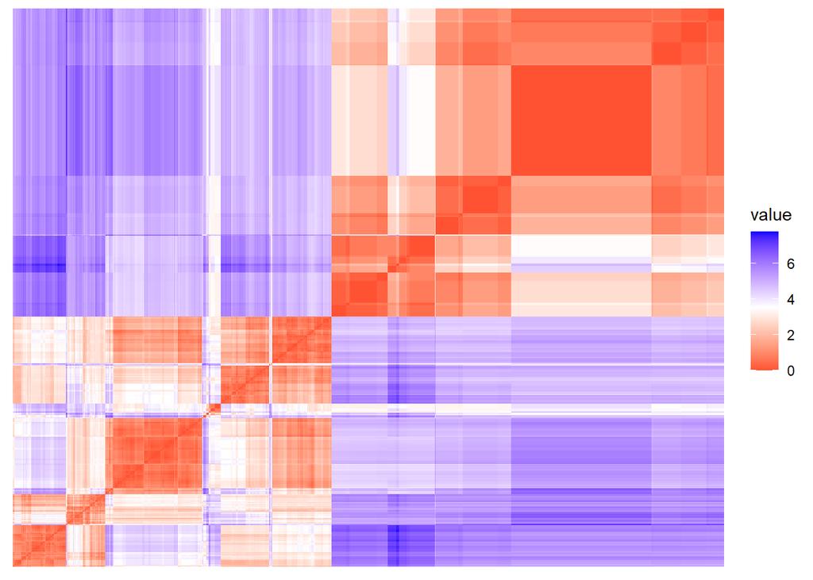

```r
db2_dist <- dist(database2[1:4000,])
fviz_dist(db2_dist, show_labels = F)
```

#### Como se puede observar en la VAT sí se observan patrones por lo que es factible el agrupamiento, confirmando el valor obtenido con el estadístico de Hopkings.

## Número de grupos o clusters

#### Para elegir el número ideal de agrupamientos o clusters se utilizarán dos metodos:

#### *Metódo de Codo:

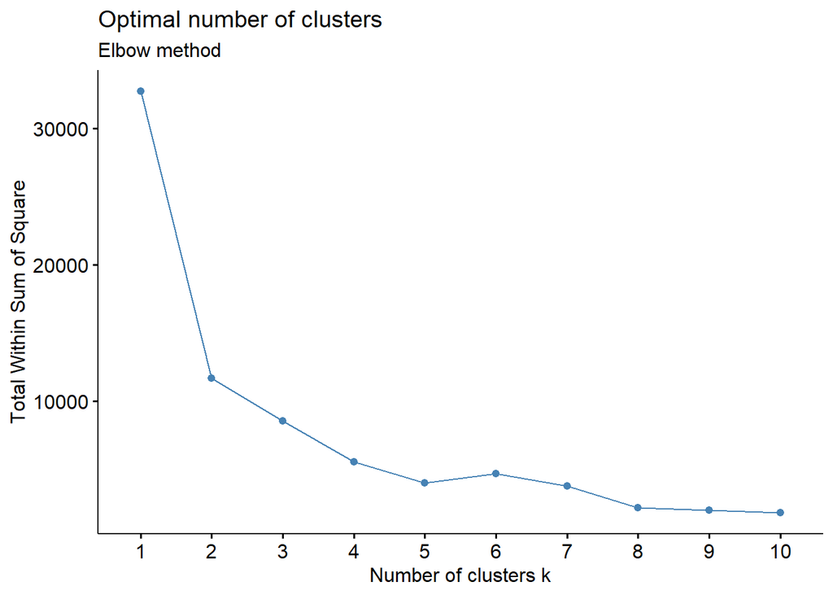

```r
fviz_nbclust(database2[1:4000,], kmeans, method = "wss") +
labs(subtitle = "Elbow method")
```

#### Según el resultado obtenido por este método, el número ideal de agrupaciones es de: 2

#### *Método de Silueta

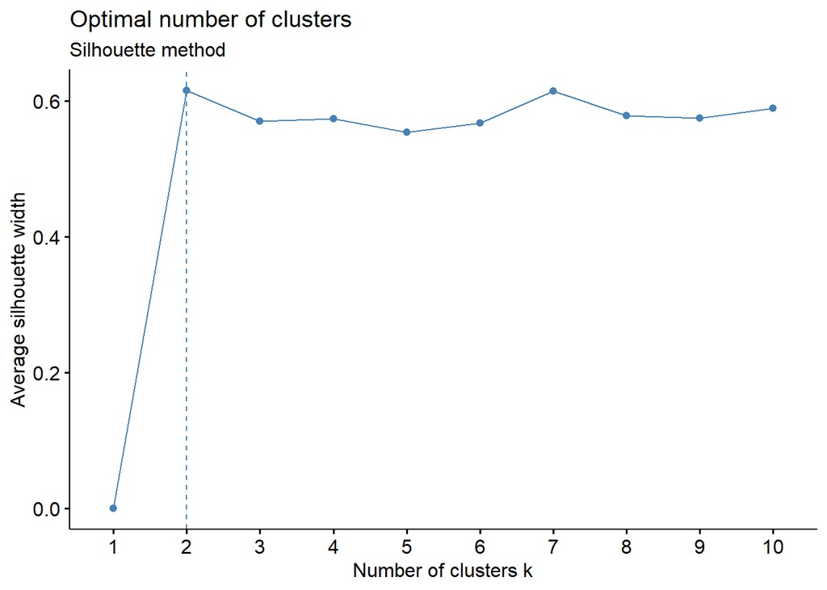

```r
fviz_nbclust(database2[1:4000,], kmeans, method = "silhouette") +
labs(subtitle = "Silhouette method")
```

#### Según el resultado obtenido por este método, el número ideal de agrupaciones es de: 2

## K-medias

#### Basándonos en ambos resultados, se utilizará el monto sugerido por el método de codo. (2 clusters)

```r
means <- kmeans(database2[1:4000,], 2, iter.max =100)
database2$means <- means$cluster
means
```

```
## K-means clustering with 2 clusters of sizes 1779, 2221
##
## Cluster means:
##        DEPREG      DEPOCU    AÑOOCU      EDADM  ESCOLAM     DEPREM
## 1  0.08961344  0.08978846 -1.424698 -0.1202987 1.274817 -0.3006762
## 2 -0.33777785 -0.33762307 -1.547331  2.9765061 2.059359  2.9710894
##
## Clustering vector:
##    [1] 1 1 1 1 1 1 1 1 1 1 1 1 1 1 1 1 1 1 1 1 1 1 1 1 1 1 1 1 1 1 1 1 1 1 1 1 1
##   [38] 1 1 1 1 1 1 1 1 1 1 1 1 1 1 1 1 1 1 1 1 1 1 1 1 1 1 1 1 1 1 1 1 1 1 1 1 1
##   [75] 1 1 1 1 1 1 1 1 1 1 1 1 1 1 1 1 1 1 1 1 1 1 1 1 1 1 1 1 1 1 1 1 1 1 1 1 1
##  [112] 1 1 1 1 1 1 1 1 1 1 1 1 1 1 1 1 1 1 1 1 1 1 1 2 1 1 1 1 1 1 1 1 1 1 1 1 1
##  [149] 1 1 1 1 1 1 1 1 1 1 1 1 1 1 1 1 1 2 1 1 1 1 1 1 1 1 1 1 1 1 1 1 1 1 1 1 1
##  [186] 1 1 1 1 1 1 1 1 1 1 1 1 1 1 1 1 1 1 1 1 1 1 1 1 1 1 1 1 1 1 1 2 1 1 1 1 1
##  [223] 1 1 1 1 1 1 1 1 1 1 1 1 1 1 1 1 1 1 1 1 1 1 1 1 1 1 1 1 1 1 1 1 1 1 1 1 1
```

[output cut: 111 more lines]

#### Por lo que se puede decir que hay un 64.3% de cohesión entre variables

```r
means$size
```

```
## [1] 1779 2221
```

#### La cardinalidad de los grupos muestra que los tamaños estan bastante equilibrados

## Clustering Jerarquico

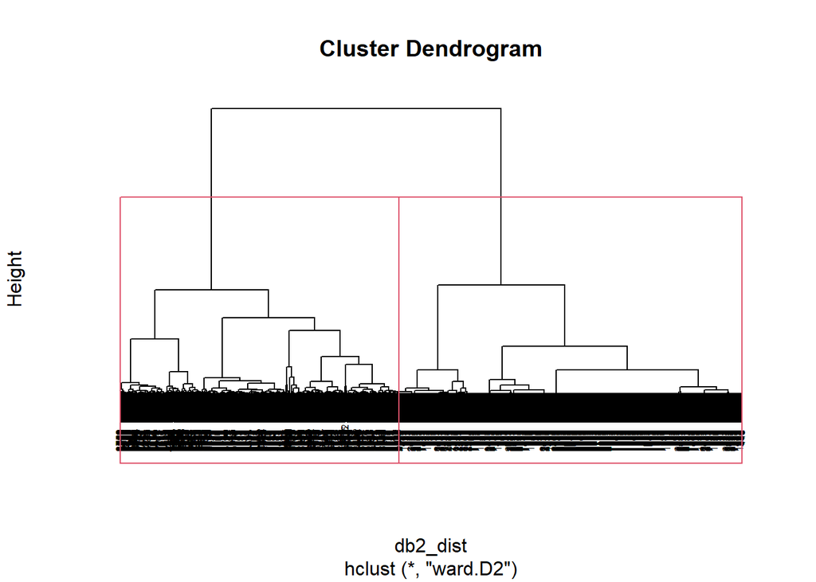

```r
hc<-hclust(db2_dist, method = "ward.D2")
plot(hc, cex=0.5, axes=FALSE) #Genera el dendograma
rect.hclust(hc,k=2)
```

## Silueta de clustering

```r
silkm<-silhouette(means$cluster,dist(database3[1:4000,]))
mean(silkm[,3])
```

```
## [1] 0.6150571
```

#### El metodo de la silueta de clustering nos indica que tenemos un valor de 0.615, lo que nos indica que es una buena agrupación, pero podría ser mejor